# NFDI4Objects Umfrageauswertung

Sophie C. Schmidt<sup>1,✉</sup>

30 Juli, 2020

<sup>1</sup> Deutsches Archäologisches Institut

<sup>✉</sup> Correspondence: Sophie C. Schmidt <sophie.schmidt@dainst.org>

Keywords:

Highlights:

# 1 Datengrundlage

Daten als csv bekommen und IPs etc entfernt. Insgesamt über 600 Antworten, dabei aber viele, die sich “nur durchgeklickt” haben oder nur Teile der Umfrage ausgefüllt haben (teilweise um die 70%).

# 2 Demographische Angaben

## 2.1 Alter und Beschäftigungsverhältnis

Zuerst einige allgemeine Statistiken zu der Teilnehmergruppe:

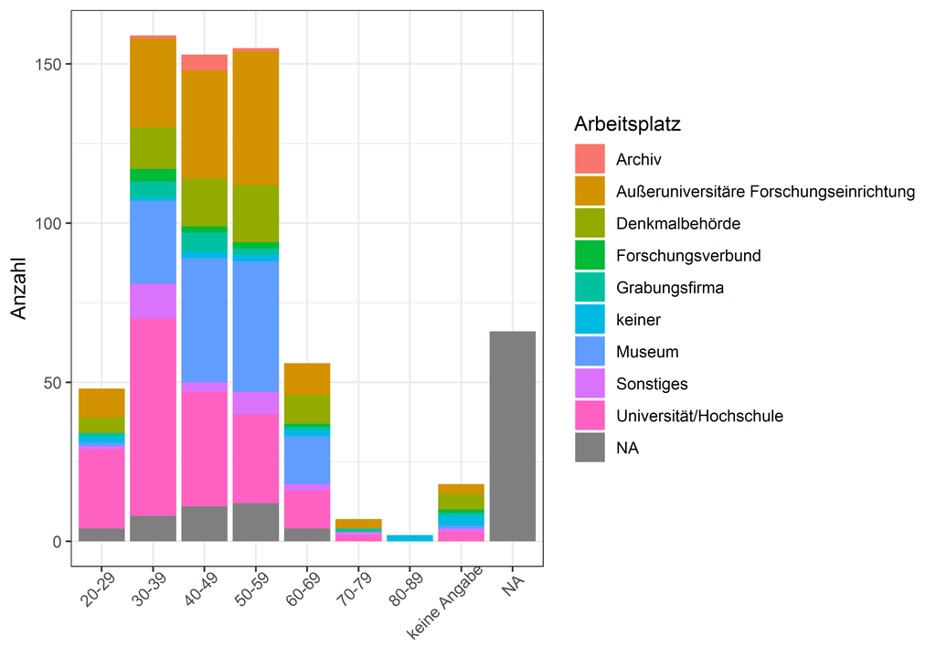

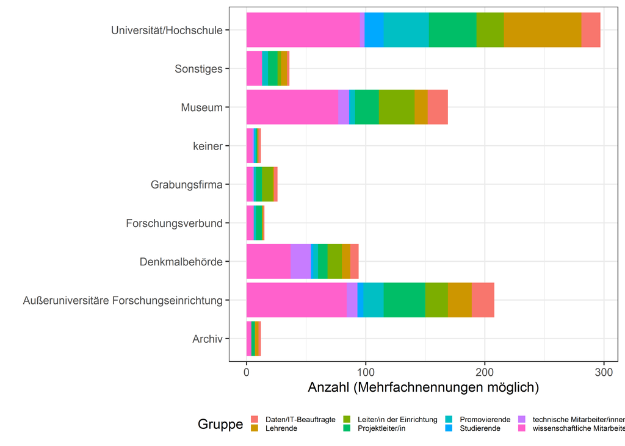

Das Gros besteht aus wissenschaftlichen Mitarbeiterinnen an der Hochschule und in Forschungseinrichtungen.

# 3 Alter und Erfahrung + Wichtung

Gibt es einen Zusammenhang zwischen dem Alter der Teilnehmenden Person, der Erfahrung die sie in digitalen Forschungsdatenmanagement hat und dem Gewicht, dass sie dem sie ihm zuweist?

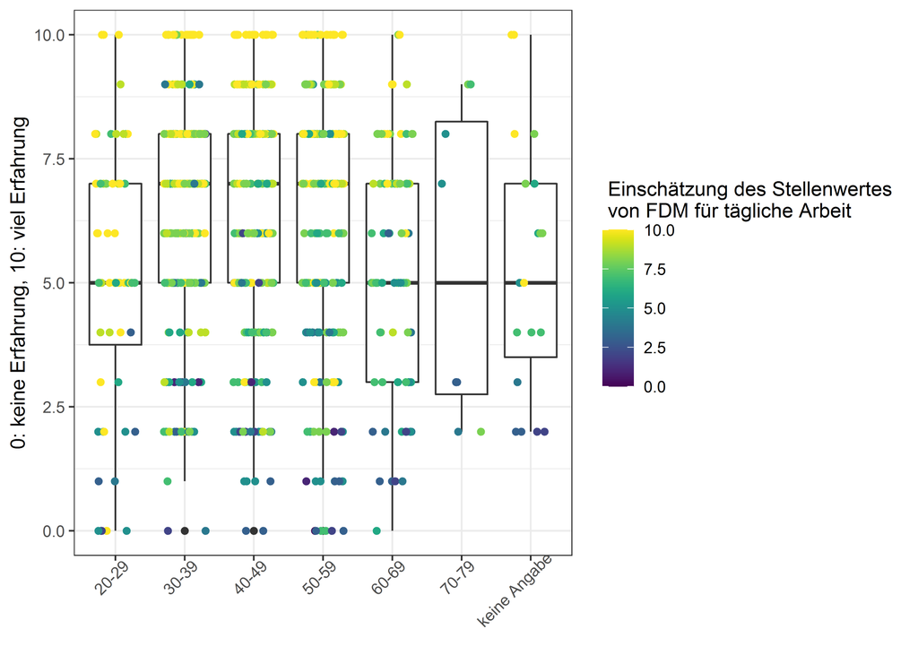

Alle Altersgruppen haben sehr gemischt Erfahrungen und Wissensstände mit digitalem Datenmanagement. Bei den Senioren (70-79) lassen sich zwei Gruppen differenzieren (viel Ahnung - wenig Ahnung), sie halten digitales Forschungsdatenmanagement allgemein für weniger wichtig für ihre tägliche Arbeit.

Jüngere Teilnehmende schätzen ihre eigene Erfahrung deutlich geringer ein als diejenigen “die im Beruf stehen” und zwischen 30 und 60 Jahre alt sind. Diese Gruppe scheint dem digitalen FDM auch den höchsten Stellenwert in ihrer täglichen Arbeit zuzuweisen.

Wer viel von Forschungsdatenmanagement hält, scheint sich häufig schon recht gut weitergebildet zu haben (oder anders herum: Einschätzung der Wichtigkeit kommt von eigener Erfahrung!). Nur wenige Personen geben an, ihre Erfahrung als mittig einzuschätzen, wenn sie FDM für wichtig halten und die gelben Punkte (sehr hoher Stellenwert des digitalen FDM für die eigene Arbeit) häufen sich im Bereich "viel Erfahrung).

Diese Ergebnisse sollten statistische getestet werden:

### 3.0.1 Test: Alter - Erfahrung mit spearmans rho

Für den Test werden die Teilnehmer entfernt, die keine Altersangabe gemacht haben.

```
#>
#>  Spearman's rank correlation rho
#>
#> data:  age_group2$beginn and age_group2$erfahrung_digfdm
#> S = 99630634, p-value = 0.2743
#> alternative hypothesis: true rho is not equal to 0
#> sample estimates:
#>         rho
#> -0.03794608
```

Aus diesem Grund wird die Vermutung eines linearen Zusammenhangs aufgegeben und nur ein Vergleich der verschiedenen Gruppen (kategorial) geführt:

### 3.0.2 Test: Alter - Erfahrung mit chi²

Der Chi-Quadrat-Test darf eigentlich für diese Daten nicht angewendet werden, da die Erwartungswerte zu gering werden (Anzahl der Teilnehmer muss auf zu viele Subgruppen aufgeteilt werden). Anhang der Residuen lassen sich trotzdem Erkenntnisse erarbeiten:

```
#>               age_group[, 7]
#> age_group[, 1]           0           1           2           3           4
#>          20-29  3.78037151  0.71632797  0.71618591 -0.55873770  0.51366887
#>          30-39 -1.43572821 -2.03436124 -0.92463709 -0.41778759 -2.11440429
#>          40-49 -0.98551875 -0.21634759  0.99269261  0.03204506  0.77354509
#>          50-59  0.92900386  1.10154466 -1.31194466 -0.68883014  1.21180188
#>          60-69 -0.32686023  1.95685903  1.07641703  1.63596430  0.51084486
#>          70-79 -0.39223227 -0.41602515  2.05497797  2.42438082 -0.66506217
#>               age_group[, 7]
#> age_group[, 1]           5           6           7           8           9
#>          20-29  1.83449846 -0.81322300 -0.09464900 -1.40801899 -1.51197903
#>          30-39  0.23609608  0.08759594  1.80625803  1.65101601 -1.09917878
#>          40-49 -1.89930415  2.33560712 -1.56846874 -0.39036707  1.59411609
#>          50-59  0.53624892 -1.64944305 -0.41881213 -0.04001503  0.65351728
#>          60-69  0.57781270 -0.25292394  0.01669451 -1.08407273 -0.96210240
#>          70-79 -1.10940039 -0.92507796 -0.28380674 -0.53218116  1.87356783
#>               age_group[, 7]
#> age_group[, 1]          10
#>          20-29 -0.60235670
#>          30-39  0.02208477
#>          40-49  0.35484035
#>          50-59  0.94291664
#>          60-69 -1.47838058
#>          70-79 -0.77831178
```

die größten Abweichungen gibt es bei der Altersgruppe der 20-29jährigen im Bereich “Erfahrung = 0”, dort sind sie überrepräsentiert, ebenso wie die Altersgruppen 60-69 und 70-70 im Bereich der niedrigen Erfahrungswerte 1-3 überrepräsentiert sind.

```
#> [1] 0.1557093
```

Cramers V ergibt einen Wert von 0,16, was auf einen schwachen Zusammenhang zwischen Altersgruppe und Erfahrung schließen lässt.

–> Conclusio: Ältere und junge haben wenig Erfahrung. Das ist nicht allzu überraschend.

Als nächstes kann die Gewichtung für die eigene Arbeit untersucht werden:

### 3.0.3 Test: Alter - Wichtung mit spearmans rho

```
#>
#>  Spearman's rank correlation rho
#>
#> data:  rank(age_group[, 1]) and age_group[, 8]
#> S = 111667326, p-value = 2.176e-06
#> alternative hypothesis: true rho is not equal to 0
#> sample estimates:
#>        rho
#> -0.1633436
```

Je älter, desto weniger wichtig. Schwacher, aber höchstsignifikanter Zusammenhang.

### 3.0.4 Test: Alter - Wichtung mit Chi²

Wie oben kann auch hier nur mit den Residualwerten gearbeitet werden.

```
#>               age_group[, 8]
#> age_group[, 1]           0           1           2           3           4
#>          20-29 -0.25943726 -0.63548891 -0.24657867  1.01551156 -0.91420749
#>          30-39 -0.57596074  0.71562822 -1.31559957 -1.14357421  0.59543767
#>          40-49 -0.49759035 -0.39839187  1.98053478 -0.47826645 -0.30596170
#>          50-59  1.46460302  0.36765411 -0.40124627 -0.16968540 -1.07119833
#>          60-69 -0.29417420 -0.72057669  0.27745145  1.24860606  1.63430113
#>          70-79 -0.09805807 -0.24019223 -0.42742521  3.58892527  1.11132477
#>               age_group[, 8]
#> age_group[, 1]           5           6           7           8           9
#>          20-29  1.06090576 -0.19917412  0.29738600 -3.38657493  0.67666495
#>          30-39 -2.56256150 -1.37171824 -0.92235505  0.73669310  2.72490066
#>          40-49  0.16873391 -0.39215848  0.29282650  0.81607905 -1.23128762
#>          50-59  1.83349695  0.87542636 -0.29005027 -0.02587174 -1.05574893
#>          60-69 -0.00858377  2.24653579  1.55781939  0.18768111 -1.67093471
#>          70-79  1.93134826 -0.69337525 -0.02843889  0.06256037 -1.07417231
#>               age_group[, 8]
#> age_group[, 1]          10
#>          20-29  2.33460911
#>          30-39  0.35915555
#>          40-49 -0.17194282
#>          50-59  0.09886962
#>          60-69 -2.16694124
#>          70-79 -1.42437571
```

Auffällig ist hier die Altersgruppe der 20-29jährigen, die dem digitalen FDM eine höhere Bedeutung zuweist als erwartet. Ältere Semester tun das wenig überraschender weise gegenteilig.

```
#> [1] 0.1553697
```

Anhand Cramers V ~ 0,16 lässt sich wieder ein schwacher Zusammenhang zwischen Alter und Gewichtung festhalten.

## 3.1 Korreliert die Einschätzung der Wichtigkeit und die Erfahrung und lassen sich darin Gruppen unterscheiden?

Für diese Frage werden die beiden Werte Einschätzung der Wichtigkeit für das eigene Arbeiten und die eigene Erfahrung gegeneinander plotten. Da in beiden Fällen keine stetigen metrischen Werte vorliegen, sondern nur mit diskreten Werten gearbeitet wurde, muss für die Visualisierung ein “jitter-Effekt” eingesetzt werden, der die Punkte ein wenig verschiebt, damit nicht alle direkt übereinander liegen.

Allgemein kann der Zusammenhang bestätigt werden (eingezeichnet blaue Linie ist lineare Regression mit Konfidenzintervall). Verschiedene Einfärbungen werden nun getestet:

### 3.1.1 Gruppenzugehörigkeit

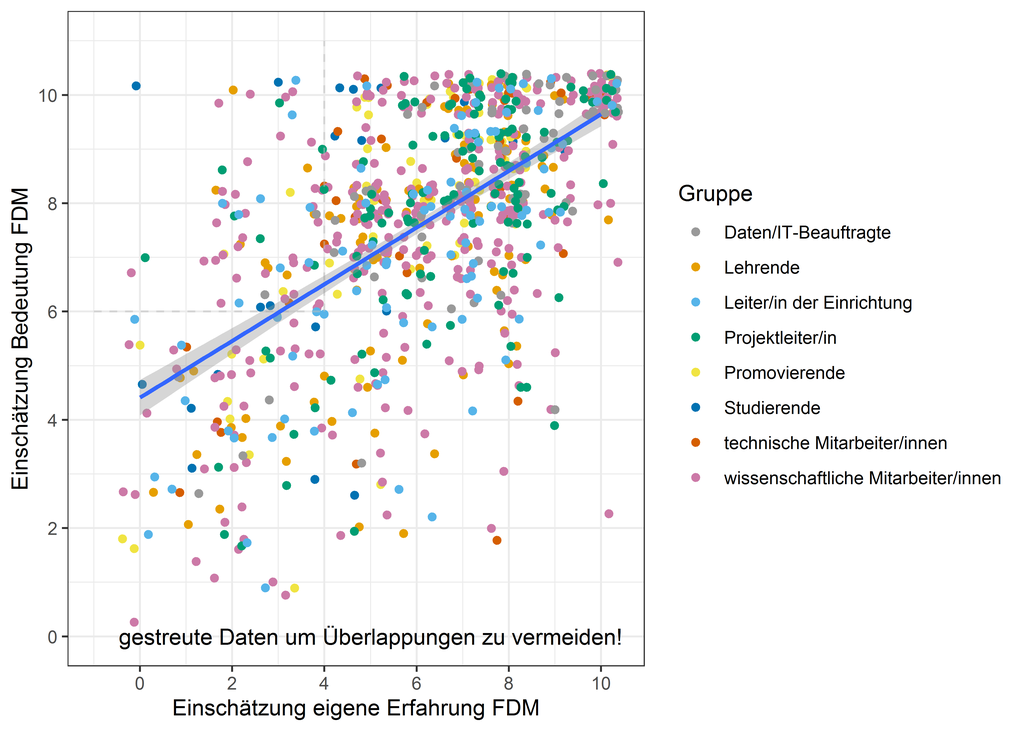

m. E. lässt sich kein Zusammenhang zwischen der Zugehörigkeit zu einer Gruppe und der Wichtung / Erfahrung im digitalen FDM finden.

Auffällig ist der/die einsame Studierende oben links in der Ecke, der/die die Bedeutung von FDM sehr hoch einschätzt, aber selber überhaupt keine Erfahrung hat. Kann dieser Person jemand bitte ganz schnell einen Datenbankenkurs anbieten?

Der Bereich “hat selber wenig Erfahrung, schätzt aber die Bedeutung hoch ein” (also Einschätzung Bedeutung FDM 6-10 und Einschätzung eigene Erfahrung FDM 0-4) ist eine Zielgruppe für uns: Das sind die Personen, die wissen, dass sie sich fortbilden müssen, denen aber evtl einfach das Angebot fehlt. Es sind darin alle Gruppen vertreten, außer Daten und IT-Beautragte.

### 3.1.2 Blickwinkel der Antwortenden

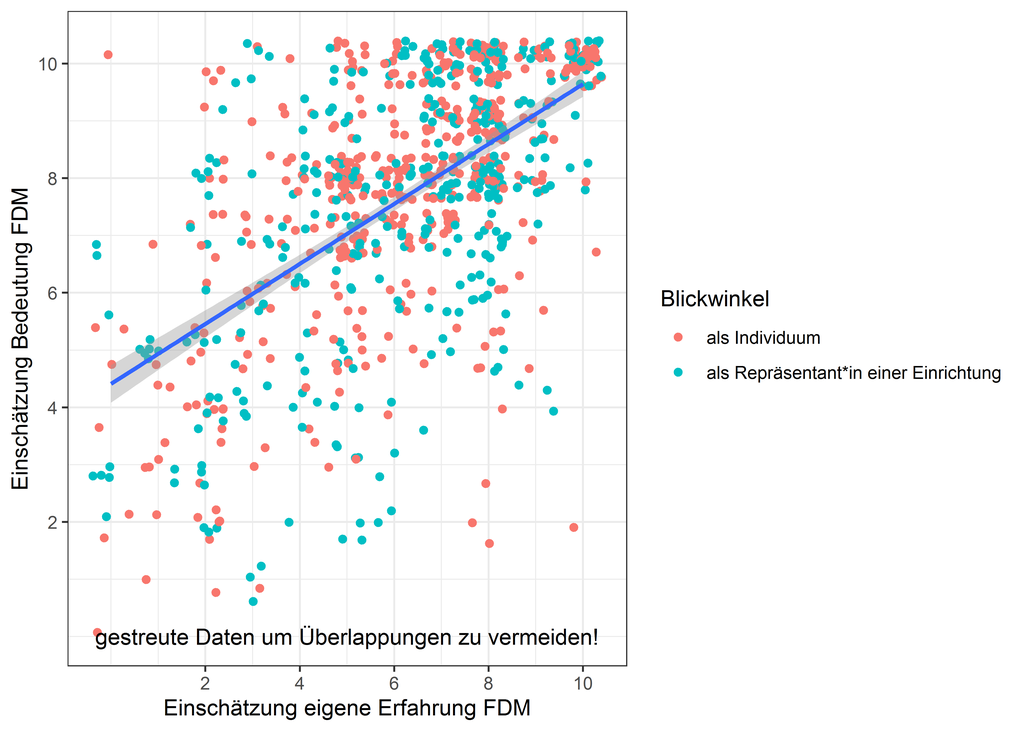

Institutionen und Individuen zeigen keine Musterungen.

### 3.1.3 Einrichtungen

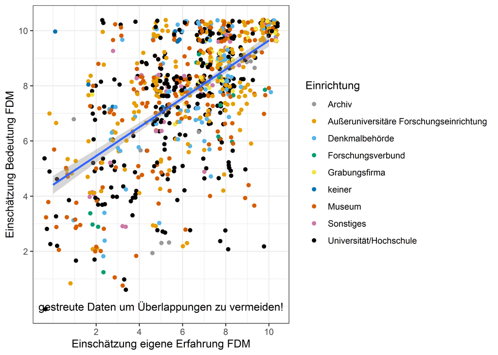

Eventuell zeigen sich Grabungsfirmen insbesondere in dem höherschätzenden Bereich. Es zeigt sich bei allen Einrichtungen eine große Heterogenität.

### 3.1.4 Teststatistiken zu dem Zusammenhang eigenes Wissen und Bedeutung

```
#>
#> Call:
#> lm(formula = erfahrung_digfdm ~ stellenwert_digfdm, data = erfahrung_group)
#>
#> Residuals:
#>     Min      1Q  Median      3Q     Max
#> -7.7089 -1.4109  0.2381  1.5626  7.4831
#>
#> Coefficients:
#>                    Estimate Std. Error t value Pr(>|t|)
#> (Intercept)         1.21895    0.24708   4.934 9.72e-07 ***
#> stellenwert_digfdm  0.64900    0.03105  20.900  < 2e-16 ***
#> ---
#> Signif. codes:  0 '***' 0.001 '**' 0.01 '*' 0.05 '.' 0.1 ' ' 1
#>
#> Residual standard error: 1.989 on 849 degrees of freedom
#>   (18 observations deleted due to missingness)
#> Multiple R-squared:  0.3397, Adjusted R-squared:  0.3389
#> F-statistic: 436.8 on 1 and 849 DF,  p-value: < 2.2e-16
```

R² ~ 0,34: moderater Zusammenhang zwischen eigener Erfahrung und dem Stellenwert der dem digitalen FDM zugeschrieben wird.

### 3.1.5 Gibt es eine Trennung zwischen Menschen mit viel und wenig Ahnung?

Hier ist es sinnvoll, sich einfach die Verteilung anzuschauen. Ist sie normalverteilt?

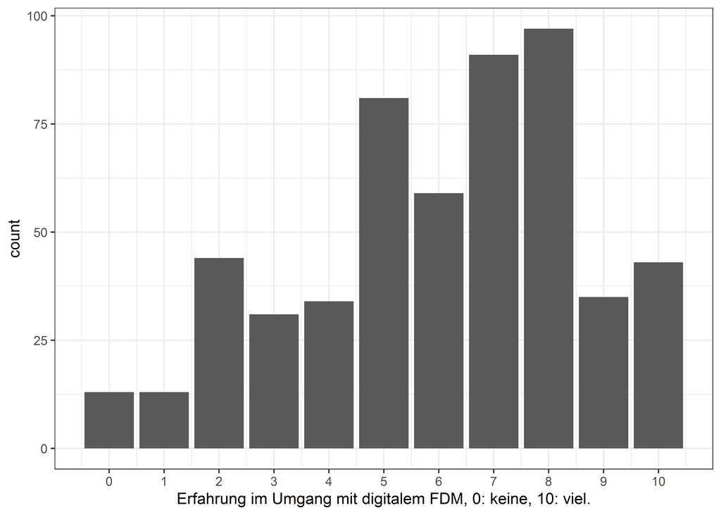

Die Erfahrung mit digitalem Datenmanagement in unserer Umfrage ist nicht-normalverteilt, sondern nach rechts verschoben:

- Median = 6
- Mittelwert = 6.0018484
- Modus = 8

Hier kann sich zeigen, dass wir vor allem Leute erreicht haben, die sich mit dem Thema schon beschäftigt haben. Es gibt einen deutlichen Anstieg zwischen der Einschätzung “4” und “5”. Hier lassen sich eventuell zwei Gruppen unterscheiden.

# 4 Welche Arbeitgeber haben ein Richtlinienkatalog?

```
#>
#>                                           ja nein weiß nicht
#>   Archiv                                   4    1          2
#>   Außeruniversitäre Forschungseinrichtung 66   36         24
#>   Denkmalbehörde                          24   23         18
#>   Forschungsverbund                        3    5          2
#>   Grabungsfirma                           15    1          1
#>   keiner                                   1    3         10
#>   Museum                                  24   67         32
#>   Sonstiges                                7    7         12
#>   Universität/Hochschule                  60   53         55
```

Für die Analyse, ob es hier nennenswerte Unterschiede gibt, entfernen wir die Angaben “weiß nicht”:

```
#>
#>                                                     ja         nein
#>   Archiv                                   0.908025222 -0.926371019
#>   Außeruniversitäre Forschungseinrichtung  1.938304471 -1.977466093
#>   Denkmalbehörde                           0.006127555 -0.006251357
#>   Forschungsverbund                       -0.534679673  0.545482374
#>   Grabungsfirma                            2.394478944 -2.442857143
#>   keiner                                  -0.728145644  0.742857143
#>   Museum                                  -3.289546822  3.356009027
#>   Sonstiges                               -0.052393683  0.053452248
#>   Universität/Hochschule                   0.312193629 -0.318501208
```

Chi nur eingeschränkt nutzbar, weil die Voraussetzungen nicht 100% erfüllt. Grabungsfirmen und außeruniversitäre Forschungseinrichrungen haben häufiger einen Richtlinienkatalog als zu erwarten währen, während insbesondere Museen keine haben.

# 5 Analyse der Software, die für Projektmanagement genutzt wird

Häufigkeit der genannten Anbieter und ob dies freie oder proprietäre Software ist:

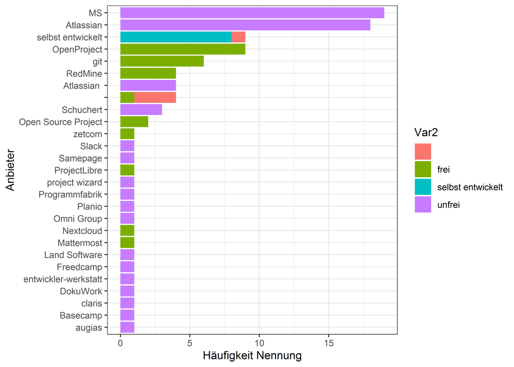

# 6 Acknowledgements

# 7 References

### 7.0.1 Colophon

The current Git commit details are:

```
#> Local:    master E:/R/N4Oumfrage
#> Head:     [c134132] 2020-07-29: setup und Rohdaten
```